# MATHTOOLS

### Lambda (filter)

Back to Top

```python
# The `filter` function applies a function that returns a boolean value to every element of a list,
# collects elements that return `True` into an iterator
# To convert iterator to a list, must pass through list()
# Usage: Filter (f, l) where f is a function that ret's bool, l is a list

print(list(filter((lambda x: x**2 > 10), (1, 2, 3, 4, 5))))

# or

#or, for simplification
ffilter = lambda f, l: list(filter(f, l))
print(ffilter((lambda x: x**2 > 10), (1, 2, 3, 4, 5)))
```

```
[4, 5]
[4, 5]
```

### Lambda (reduce)

Back to Top

```python
# Applies a function of two arguments cumulatively to the items of a list
# Usage: reduce(f, l, v0)
# `f` is a function that takes two arguments, i.e., `f(v, x)`
#   - `v` is the value of f in the previous iteration
#   - `x` takes values in l consecutively
# `l` is an iterable, e.g., a list or a tuple, that can be indexed

from functools import reduce
Sum = lambda l: reduce((lambda x, y: x+y), l) # A function l that returns the reduction
                                                # (function sum x and y sum x and y) of list l
l = [2, 3, 4]
print(sum(l))
print(Sum(l))

pwr = lambda l: reduce((lambda x, y: x**y), l) # returns (2^3)^4 = 8^4 = 4096
pWr = lambda l: reduce((lambda x, y: y**x), l) # returns (3^2)^4 = 4^9 = 262144
print(pwr(l))
print(pWr(l))
```

```
9
9
4096
262144
```

### Closure & List functions

Back to Top

```python
# Simple ex:
# For n in 0, 1, 2, ... make list of x^n
l = []
L = []
for n in range(0, 4): # n = 0, 1, 2, 3
    l = l + [lambda x: x**n] # Incorrect, n called at last known value = end of loop = 3

for n in range(0, 4):
    L = L + [lambda x, i=n: x**i] # Correct, i set at each individual value of n


print('n=', n)
print(l[0](2), l[1](2), l[2](2), l[3](2)) # (l[n](2)) returning 2^3, last known val of n
print(L[0](2), L[1](2), L[2](2), L[3](2)) # (l[i](4)) returning 2^i
```

```
n= 3
8 8 8 8
1 2 4 8
```

## Solving Equations

Back to Top

### Root Finding: Newton's Method

Back to Top

Ex: $e^{-2*z}-1+z$

```python
import numpy as np
def Newton(f, df, x0, epsilon):
  fx = f(x0)
  while np.abs(fx) >= epsilon:
    df0 = df(x0)
    x0 = x0 - fx / df0
    fx = f(x0)
  return x0

def f(Z):
    return np.exp(-2*Z)-1+Z
def df(Z):
    return -2*np.exp(-2*Z)+1

Newton(f, df, 0.5, 1e-6)
```

```
0.7968121582003599
```

+ Note: Python cannot compute root of $\sqrt[3]{x}$ using newton's method due to negatives.

**Solution:** Use $\text{sign}(x) \sqrt[3](|x|)$,

```python
x=-0.001
(2*(x>0)-1) * abs(x)**(1/3) #Note: 1st part returns -1 or 1 according to sign of x
```

```
-0.10000000000000002
```

### Root finding: Quadratic formula

Back to Top

Ex:

1. Interseciton of $y = -1$ with ellipse $$x^2+xy+2y^2+2x+2y=1$$

Soln: Plug in $y=-1$, solve using quadratic formula: $$x = \frac{-b\pm\sqrt{b^2-4ac}}{2a}$$

2. Distance of roots from the origin

Soln: Distance eqn $$d = \sqrt{(x_2-x_1)^{2}+(y_2-y_1)^{2}}$$

```python
import numpy as np

# Set variables
a, b, c, y = 1, 1, -1, -1

# Compute discriminant
delta = np.sqrt(b**2-4*a*c)

# Find solutions and print
x1 = (-b+delta)/(2*a)
x2 = (-b-delta)/(2*a)
print("1. x1=", x1, "x2=", x2)


# Calculate distance of x1, x2 from origin; d1, d2
d1 = np.sqrt(x1**2+y**2)
d2 = np.sqrt(x2**2+y**2)
print("2. D1=", d1, "D2=", d2)
```

```
1. x1= 0.6180339887498949 x2= -1.618033988749895
2. D1= 1.1755705045849463 D2= 1.902113032590307
```

### Root finding: Bisection method

Back to Top

Guarantees a root, including in non-differentiable functions.

Idea:

- If $f(a)$, $f(b)$ have different signs, there's a root in $[a, b]$.
- For $c = \frac{a+b}{2}$, f(c) has a different sign from either f(a) or f(b). Whichever has a different sign gives a new interval closer to root.
- Continue, closing in on root.

Ex: solve the final size relationship $$ 1-Z = e^{-\mathcal R_0Z}$$ with $\mathcal R_0=2$

```python
from numpy import exp

R0 = 2
# a and b are the endpoints of the interval
a = 0.01
b = 1
# the function value at the two end points
fa = exp(-R0*a) - 1 + a
fb = exp(-R0*b) - 1 + b

# the error
epsilon = 1e-3

if fa == 0:
    print("the root is", a)
elif fb == 0: # elif means else if
    print("the root is", b)
elif fa*fb > 0:
    print("f(a) and f(b) must have same signs")
else:
    # the guess if the mid point of [a,b]
    x = (a+b)/2
    fx = exp(-R0*x) - 1 + x
    while (b - a) / 2 > epsilon and fx != 0: # if f(x) == 0 then x is the root
        if fx * fa < 0 : # the next interval is [a,x]
            b = x
            fb = fx
        else: # the next interval is [x, b]
            a = x
            fa = fx
        x = (a+b)/2
        fx = exp(-R0*x) - 1 + x
        print("x =", x)
    print("the root is", x)
```

```
x = 0.7525
x = 0.87625
x = 0.814375
x = 0.7834375
x = 0.7989062499999999
x = 0.791171875
x = 0.7950390624999999
x = 0.7969726562499999
x = 0.7960058593749999
the root is 0.7960058593749999
```

### Root finding: fsolve, root_scalar

Back to Top

```python
from scipy.optimize import fsolve, root_scalar

f = lambda x, n: x**n + 1
df = lambda x, n: n*x**(n-1)

solnF = fsolve(f, x0=1, args=3)
solnR = root_scalar(f, args = 3, x0=1, fprime = df)
print(solnF)
print(solnR)


# Note: Maxfev determines max number of 'calls to function' (iterations)
```

```
[-1.]
      converged: True
           flag: converged
 function_calls: 18
     iterations: 9
           root: -1.0
```

## Arrays/Matrices

Back to Top

### Matrix

Back to Top

```python
import numpy as np
A = np.array([[1,2,3], [4,5,6], [7,8,9]])

print(A.shape)

print(A[1]) # Prints row 2
print(A[:,2]) # Prints column 3
print(A[1, 2])
```

```
(3, 3)
[4 5 6]
[3 6 9]
6
```

### Matrix op's

Back to Top

```python
import numpy as np

from numpy import array

a = np.array([1, 2, 3])
b = np.array([4,5,6])
c = [1, 2, 3]
d = [4, 5, 6]

print("a =", a)
print("b =", b)
print("c =", c)
print("d =", d)
print("a + b =", a+b)
print("a - b =", a-b)
print("c + d =", c+d) # Concatenates lists, add/sub/mult/div requires matrices
# print("c - d =", c-d) # Throws error - not concatenation

print("a * b =", a*b)
print("c * 10 =", c*10)
print("a / b =", a/b)

# Dot product:
dot = sum(a*b)
print(dot)
```

```
a = [1 2 3]
b = [4 5 6]
c = [1, 2, 3]
d = [4, 5, 6]
a + b = [5 7 9]
a - b = [-3 -3 -3]
c + d = [1, 2, 3, 4, 5, 6]
a * b = [ 4 10 18]
c * 10 = [1, 2, 3, 1, 2, 3, 1, 2, 3, 1, 2, 3, 1, 2, 3, 1, 2, 3, 1, 2, 3, 1, 2, 3, 1, 2, 3, 1, 2, 3]
a / b = [0.25 0.4  0.5 ]
32
```

### Matrix multiplication

Back to Top

```python
# Reminder: Given mxn, nxp matrices, returns mxp, where for ixj i=rows, j=col's.
import numpy as np

A = np.array([[1,2,3], [4,5,6], [7,8,9]])
print(np.matmul(A, [1,1,1]))
print(np.matmul([1,1,1], A))
```

```
[ 6 15 24]
[12 15 18]
```

### Ex: SIR model, graph wrt time

Back to Top

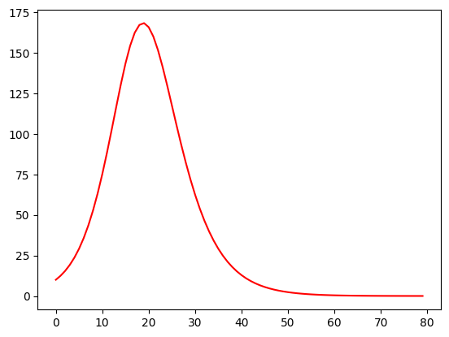

```python
import numpy

def SIR(times, I0, beta, gamma, N):
    # create the matrix
    V = np.zeros((len(times), 3))
    # the initial condition is the first row
    S = N-I0
    I = I0
    R = 0
    V[0] = [S, I, R]
    # for each successive time point, compute the number of infections and recoveries
    # and compute the S, I and R
    for t in range(1,len(times)):
        infections = beta * S * I / N
        recoveries = gamma * I
        S = S - infections
        I = I + infections - recoveries
        R = R + recoveries
        V[t] = [S, I, R]
    return V

t = range(0, 80)
V = SIR(t, 10, 0.5, 0.25, 1000)

from matplotlib.pyplot import plot
# I is the second column of V, i.e., V[:,1]
plot(t, V[:,1], '-r')
```

## Difference Equations

Back to Top

Equation of the form $$ X_{n+1} = f(X) $$

### Generic difference equation solver

Back to Top

```python
from numpy import zeros

# Takes function f, x0, p: List of parameters, N: Number of time pt's
# Returns a matrix, each row corresponds to a time point, each column is a variable

def difference(f, x0, p, N):
    if type(x0) is list:
        m = len(x0) # the dimension of the difference equations (the number of equations)
    else:
        m = 1
    V = zeros((N+1, m)) # N = the number of time points, not incl. 0
    V[0] = x0
    for i in range(1, N+1):
        if p is None:
            V[i] = f(V[i-1])
        else:
            V[i] = f(V[i-1], p)
    return(V)
```

### Ex: Logistic equation, periodicity & graphing attractors

Back to Top

$$ X_{n+1} = rX_{n}\left(1-\frac{X_n}{K}\right)$$ Let $x_n = X_n/K$, then $$ x_{n+1} = rx_{n}\left(1-x_n\right)$$

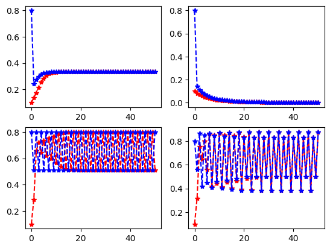

```python
import matplotlib.pyplot as plt

# Define logistic function
logistic = lambda x, r: r*x*(1-x)

# Define axes for graphs
fig, axs = plt.subplots(2, 2)

# Not periodic
x1 = difference(logistic, x0=0.1, p=1.5, N=50)
x2 = difference(logistic, x0=0.8, p=1.5, N=50)
axs[0,0].plot(range(0, 51), x1, '--*r', range(0, 51), x2, '--*b')

x3 = difference(logistic, x0=0.1, p=0.9, N=50)
x4 = difference(logistic, x0=0.8, p=0.9, N=50)
axs[0,1].plot(range(0, 51), x3, '--*r', range(0, 51), x4, '--*b')

x5 = difference(logistic, x0=0.1, p=3.2, N=50)
x6 = difference(logistic, x0=0.8, p=3.2, N=50)
axs[1,0].plot(range(0, 51), x5, '--*r', range(0, 51), x6, '--*b')

x7 = difference(logistic, x0=0.1, p=3.5, N=50)
x8 = difference(logistic, x0=0.8, p=3.5, N=50)
axs[1,1].plot(range(0, 51), x7, '--*r', range(0, 51), x8, '--*b')
```

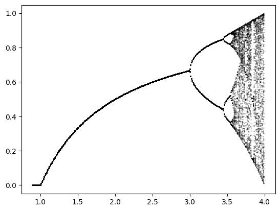

```python
import numpy as np
import matplotlib.pyplot as plt

for r in np.arange(0.9, 4.3, 0.01):
    ys = difference(logistic, x0=0.5, p=r, N=1000)
    plt.plot([r]*100, ys[-100:], 'k.', markersize=0.5)
```

### Higher-order difference equations***

Back to Top

General: Use a simple array, index n, n-1, ... , n-i

### Fixed points

Back to Top

Can be solved from the equation $f(x)-x=0$  
+ Example: the fixed point of the logistic map $x_{n+1}=rx_n(1-x_n)$ at $r=1.5$

```python
# Solving fixed point equation of logistic map

def f(x, r):
    return r*x*(1-x) - x

from scipy.optimize import root_scalar

def df(x, r):
    return r - 2*r*x - 1

root_scalar(f, args=1.5, x0=0.5, fprime=df)
```

```
      converged: True
           flag: converged
 function_calls: 10
     iterations: 5
           root: 0.3333333333333334
```

### T - periodic orbits

Back to Top

```python
from functools import reduce
from scipy.optimize import fsolve

# Where x, f(x), f(f(x)) .... F_n(c) cycles.
# One orbit/n-period = Full rotation - 1

# Helps to be able to calculate f(f(f(...(x)))) = F_n(x)
logistic = lambda x: r*x*(1-x)

# Fancy method:
compose = lambda f, g: ( lambda x: f(g(x)) )
identity = lambda x : x
composite = lambda f, n: identity if n == 0 else reduce(compose, [f] * n)

r = 3.83
x = fsolve(lambda x: composite(logistic, 3)(x)-x, 0.6) # Gives f(f(f(x)))
for i in [0, 1, 2, 3]:
    print(composite(logistic, i)(x)) # Prints a 3-period

print("")

# Simple method:
def Composite(f, n):
    if n == 0:
        return identity
    return reduce(compose, [f] * n)

for i in [0, 1, 2, 3]:
    print(Composite(logistic, i)(x)) # Prints a 3-period

#---------------------------------------------------------#
# Example w many variables:

# # Define composition functions
# compose = lambda f, g: (lambda x, p: f(g(x, p), p))
# identity = lambda x, n: x
# composite = lambda f, n: identity if n == 0 else reduce(compose, [f] * n) # Ask at office hours! What would this give? (Not f(x))

# # Get initial x-value
# x = fsolve(lambda x: composite(f, 2)(x, p)-x, 0.5) # Gives f(f(x))

# # Compose repeatedly
# for i in range(1, 100):
#     print(composite(f, i)(x, p))
```

```
[0.52400053]
[0.95529382]
[0.16356986]
[0.52400053]

[0.52400053]
[0.95529382]
[0.16356986]
[0.52400053]
```

## Numerical differentiation

Back to Top

### Newton's method

Back to Top

```python
from math import fabs

# numerical differentiation using the central difference
def d(f, x, h=1e-5):
    return (f(x+h) - f(x-h)) / (2*h)

# numerical differentiation using the forward difference
def D(f, x, h=1e-8):
    return (f(x+h) - f(x)) / h

# solve f(x)=0 using the Newton's method with an initial guess x0
# fprime is f'(x), or None for numerical differentiation
# D is the function used for numerical differentiation
# epsilon is the termination condition, i.e, |f(x)|<epsilon
# maxiter is the maximum number of iterations, because Newton's method may not converge
# returns the root and the numer of iterations performed
def Newton(f, x0, fprime=None, D=d, epsilon=1e-6, maxiter=1000):
    f0 = f(x0)
    for i in range(1, maxiter+1):
        df = D(f, x0) if fprime is None else fprime(x0)
        x1 = x0 - f0 / df
        f1 = f(x1)
        if fabs(f1) < epsilon:
            break
        x0 = x1
        f0 = f1
    if i == maxiter:
        print ("maximum number of iterations reached without convergence")
    return x1, i


# Ex: Use
from math import exp

R0 = 2
f = lambda Z: 1 - Z - exp(-R0*Z)
df = lambda Z: -1 + R0*exp(-R0*Z) # Analytic derivative
Z, iter = Newton(f, x0 = 0.5, fprime = df)
print("analytic derivative:", Z, "iterations:", iter)

Z, iter = Newton(f, x0 = 0.5)
print("central difference:", Z, "iterations:", iter)

Z, iter = Newton(f, x0 = 0.5, D=D)
print("forward difference:", Z, "iterations:", iter)
```

```
analytic derivative: 0.7968121582003599 iterations: 4
central difference: 0.7968121582003495 iterations: 4
forward difference: 0.7968121582034714 iterations: 4
```

### Euler's method (Initial val problems)

Back to Top

$$x'=f(t,x),\;x(t_0)=x_0$$

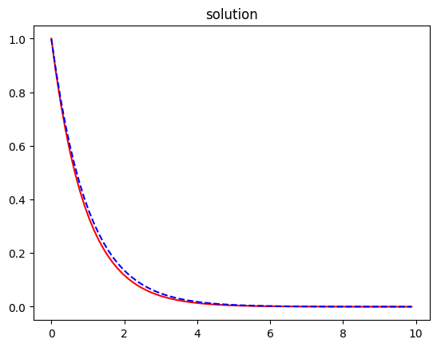

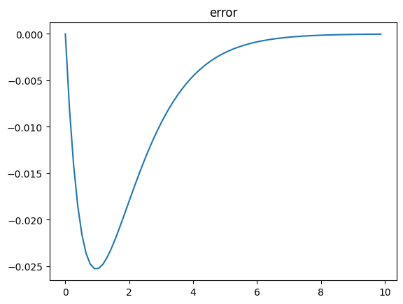

```python
from numpy import zeros

# solve x'=f(t,x) using the Euler method
# t is an array of time points, t[0]=t0
# x0 = x(t0) is the intial condition of the ODE
# return an array of x values at the corresponding time points in t
def Euler(f, t, x0):
    n = len(t)
    x = zeros(n) # solution
    x[0] = x0
    for i in range(1, n): # starting from t[1]
        h = t[i] - t[i-1]
        x[i] = x[i-1] + h * f(t[i-1], x[i-1])
    return x

from numpy import arange, exp

# solve x'=-x
t = arange(0, 10, 0.13)
f = lambda t, x: -x
x = Euler(f, t, 1)
# true solution
X = exp(-t)

from matplotlib.pyplot import plot, figure, title
figure(0)
plot(t, x, '-r', t, X, '--b')
title("solution")
figure(1)
error = x-X
plot(t, x-X)
title("error")
```

### Implicit (backwards) Euler's method

Back to Top

$$x_{n-1} = x_n - hf(t_n, x_n)$$

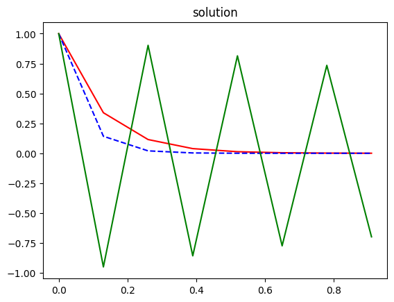

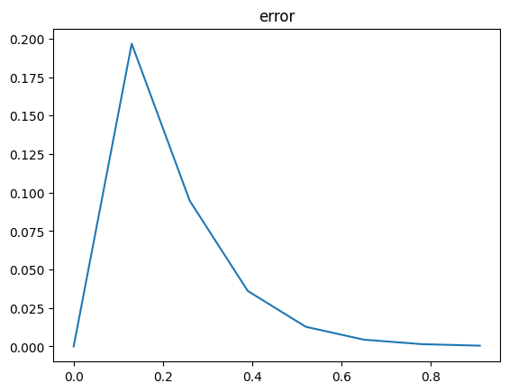

```python
from numpy import zeros

# solve x'=f(t,x) using the implicitly Euler method
# using Newton's method to solve the implicit relationship
# epsilon gives termination condition for Newton's method
# t is an array of time points, t[0]=t0
# x0 = x(t0) is the initial condition of the ODE
# return an array of x values at the corresponding time points in t
def ImplicitEuler(f, t, x0, epsilon=1e-8):
    n = len(t)
    x = zeros(n) # solution
    x[0] = x0
    g = lambda x0, x1, h: x1 - h*f(t, x1) - x0
    for i in range(1, n): # starting from t[1]
        h = t[i] - t[i-1]
        x[i], iter = Newton(lambda xi: g(x[i-1], xi, h), x[i-1], epsilon=epsilon) # Use this or root scalar, etc.
    return x

from numpy import arange, exp
t = arange(0, 1, 0.13)

# solve x'=-15x
f = lambda t, x: -15*x
x = ImplicitEuler(f, t, 1)

xe = Euler(f, t, 1)

# True soln
X = exp(-15*t)

figure(0)
plot(t, x, '-r', t, X, '--b', t, xe, '-g')
title("solution")
figure(1)
error = x-X
plot(t, error)
title("error")
```

### Local extrema

Back to Top

```
[0.5]
```

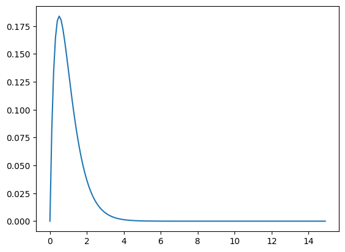

```python
from scipy.optimize import fsolve

def d(f, x, h=1e-5):
    return (f(x+h) - f(x-h)) / (2*h)

f = lambda x: x*exp(-2*x)
df = lambda x: d(f, x)

# Note: In exam, should graph in order to ensure a correct solution
x = arange(0, 15, 0.1)
plot(x, f(x))

print(fsolve(df, 0.1))
```

### Point of inflection

Back to Top

Where f''(x) = 0, f'(x) changes sign

### Ex: Maximizing $x_5$ ($f(f(f(f(f(x)))))$)

Back to Top

```python
# Import necessary modules
from scipy.optimize import fsolve
from numpy import exp, arange, zeros
from functools import reduce

f = lambda x: x*exp(-x)
df = lambda f, h=1e-8: lambda x: (f(x+h)-f(x))/h  # Rewrite as regular function

compose = lambda f, g: (lambda x: f(g(x)))
identity = lambda x, n: x
composite = lambda f, n: identity if n == 0 else reduce(compose, [f] * n)

# composite = lambda f, n: (lambda x, n: x) if n == 0 else reduce(lambda f, g: (lambda x: f(g(x))), [f] * n)

fx5 = composite(f, 5)

soln = fsolve(df(fx5), x0 = 4)
print(soln)
```

```
[0.99999992]
```

```python
# Ex: critical pt of cosh near x0=1.4
import numdifftools as nd
from numpy import cosh

f = lambda x: cosh(x**2-2)
df = nd.Derivative(f)

cp = fsolve(df, 1.4)
print(cp, df(cp))
d2f = nd.Derivative(f, n=2)
print(d2f(cp))
```

```
[1.41421356] [1.84622094e-14]
[8.]
```

### Numdifftools

Back to Top

```
Solution:  [1.15977131]
Verify concavity: -44103.42466100757
Value at solution is negative, thus is a max by 2nd derivative test.
Note that max of graph occurs at solution:
```

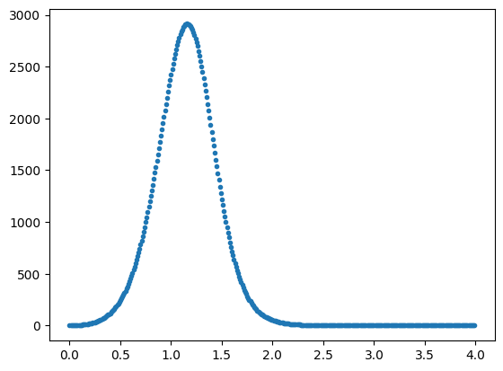

```python
# Easy way to take a derivative
# Usage: dif = nd.Derivative(f, n=i), dif(x) gives ith derivative at x
import numdifftools as nd
import matplotlib.pyplot as plt

# Ex:
import numpy as np

def SIS(t, i0, beta, gamma, n):
    iN = lambda ix: (n-ix)*(1-np.exp((-beta*ix)/n)) - gamma*i0 + ix
    arr = np.zeros(t+1)
    arr[0]= i0
    for i in range(1, t+1):
        arr[i] = iN(arr[i-1])
    return arr
#---------------------------------------#

from scipy.optimize import fsolve
import numdifftools as nd

t, i0, gamma, n = 10, 1, 0.25, 2000

# Rewrite the function to take only beta as an argument,
# Output only I_10
f = lambda beta: SIS(t, i0, beta, gamma, n)[10]

df, ddf, dddf = nd.Derivative(f, n=1), nd.Derivative(f, n=2), nd.Derivative(f, n=3)

x = fsolve(ddf, 1)
print("Solution: ", x)

# The rest of the code is for verification purposes and is not a part of the solution
print("Verify concavity:", dddf(x))
print("Value at solution is negative, thus is a max by 2nd derivative test.")

print("Note that max of graph occurs at solution:")
ys = []
xs = []
for beta in np.arange(0, 4, 0.01):
    ys.append(df(beta))
    xs.append(beta)
plt.plot(xs, ys, '.')
```

## Classes & Objects

Back to Top

```python
# Ex: Class w method
class FreeFall:
    def __init__(self, v0, x0): # the constructor
        self.v0 = v0 # an instance variable
        self.x0 = x0 # another instance variable.

    g = 9.8 # a class variable

    def value(self, t): # a method
        # instance variables and class variables can all be accessed by the self.variable form
        return -self.g/2 * t**2 + self.v0 * t + self.x0


# Ex: Instances w individual variables
x1 = FreeFall(v0 = 1, x0 = 0)
print("x1.v0=", x1.v0)
print("x1.value(0)=", x1.value(t=0)) # note we do not pass self
print("x1.g=", x1.g)

x2 = FreeFall(v0 = 0, x0 = 1)
print("x2.v0=", x2.v0)
print("x2.value(0)=", x2.value(t=0))
print("x2.g=", x2.g, "=x1.g")


# Ex: Changing class vs instance variables
FreeFall.g = 0.376 * 9.8
print("x1.g=", x1.g)
print("x2.g=", x2.g, "=x1.g")

x2.g = 0
print("x1.g=", x1.g)
print("x2.g=", x2.g)
x2.g = 9.8


# Ex: Methods as functions
f = x1.value
print(f(0), "=", x1.x0)

x1.x0 = 10
print(f(0), "=", x1.x0)


# Ex: USing __call__ to make instances
# behave like functions;
# Append methods to a class
FreeFall.__call__ = lambda self, t: self.value(t)

print(x1(1))
print(x2(2))

# Useful: For ex, solve time for x1 to hit the ground:
from scipy.optimize import fsolve
fsolve(x1, x0=1.0)
```

```
x1.v0= 1
x1.value(0)= 0.0
x1.g= 9.8
x2.v0= 0
x2.value(0)= 1.0
x2.g= 9.8 =x1.g
x1.g= 3.6848
x2.g= 3.6848 =x1.g
x1.g= 3.6848
x2.g= 0
0.0 = 0
10.0 = 10
9.1576
-18.6
```

```
array([2.61688145])
```

```python
# Ex: Reiplement complex class
from math import sqrt

class Complex:
    def __init__(self, real = 0, imag = 0): # by default, Complex() returns 0+0i
        self.real = real
        self.imag = imag

    def __add__(self, x):
        if isinstance(x, Complex):
            return Complex(self.real + x.real, self.imag + x.imag)
        return Complex(self.real + x, self.imag)

    def __sub__(self, x):
        if isinstance(x, Complex):
            return Complex(self.real - x.real, self.imag - x.imag)
        return Complex(self.real - x, self.imag)

    def __neg__(self):
        return Complex(-self.real, -self.imag)

    def __pos__(self):
        return self

    def __mul__(self, x):
        if isinstance(x, Complex):
            return Complex(self.real * x.real - self.imag * x.imag,
                          self.real * x.imag + self.imag * x.real)
        return Complex(self.real * x, self.imag * x)

    def __truediv__(self, x):
        if isinstance(x, Complex):
            return self * x.conj() / x.modulus()
        return Complex(self.real / x, self.imag / x)

    def __repr__(self):
        return __str__(self)

    def __str__(self):
        if self.imag == 0:
            simag = ""
        elif self.imag == 1:
            simag = "i"
        elif self.imag == -1:
            simag = "-i"
        else:
            simag = str(self.imag) + "i"
        if self.real == 0:
            sreal = ""
        else:
            sreal = str(self.real)
        sadd = "+" if self.imag > 0 and self.real != 0 else ""
        return  sreal + sadd + simag

    def conj(self):
        return Complex(self.real, -self.imag)

    def modulus(self):
        return sqrt(self.real * self.real + self.imag * self.imag)

    conjugate = conj # an alias for conj

# the imaginary unit
i = Complex(0, 1)
```

# **PART 2**

Back to Top

## Libraries

Back to Top

```python
# From MT1:

# Numpy:
import numpy as np
# Used for
# - np.exp(x) Exponential fn
# - Plotting:
#       - np.arange(startVal, endVal, stepSize),
#       - np.linspace(startVal, endVal, numSteps)
# - np.sqrt(x) Sqrt
# - np.abs(x) Absolute val
# - matmul(A, B) Multiplies two matrixes, reminder must be
# - np.zeros((m, n)) Returns mxn matrix of zeros

# Matplotlib.pyplot
import matplotlib.pyplot as plt

# Root finding:
# 1. Root scalar
from scipy.optimize import root_scalar
# Takes arguments f, fprime(req'd for newton), args=()(required for function with args),
# bracket=[](req'd for bisect), x0(req'd), x1, xtol(absolute tolerance for termination),
# rtol, maxiter(max iterations), method="..."
# help(root_scalar)
# Note: Method must be in quotes, i.e. "newton"
from scipy.optimize import fsolve
# Takes args f, x0, args=(), xtol, maxfev(max num calls to function)
# Can solve multi-dimensional equations, such as SIR model

# Use to take derivatives
import numdifftools as nd

# -----------------------------

# MT2:
# More numpy:
# - numpy.linalg:
from numpy.linalg import solve
    # Used to solve (for x) matrix equations of the form ax=b
from numpy.linalg import norm
    # Used to find norm of vectors, matrices
from numpy.linalg import eig
    # Used to find eigenvals, eigenvecs
# - numpy.polynomial.polynomial:
from numpy.polynomial.polynomial import Polynomial
    # Used to create polynomials (See lin alg)
# - numpy.array:
from numpy import array # or...
import numpy as np # use np.array
# - numpy.matrix:
print(np.matrix(A))
    # Prints array as a matrix
# - numpy.random:
import numpy.random as rd
# - numpy.cumsum:
print(numpy.cumsum([1, 2, 3]))
# Animation
import matplotlib.pyplot as plt
from IPython.display import HTML
from matplotlib.animation import FuncAnimation
# Pandas
import pandas as pd
# Reader
from csv import reader
# DictReader
from csv import DictReader
# Sympy
# Note: May need to install display on server.
# Run all before exam to see if any fail
from sympy import *
from IPython.display import display
# Integrate
from scipy.integrate import quad
```

```
[[1 2 3]
 [4 5 6]
 [7 8 9]]
[1 3 6]
```

## Basics (More in Part 1)

Back to Top

### Plotting

Back to Top

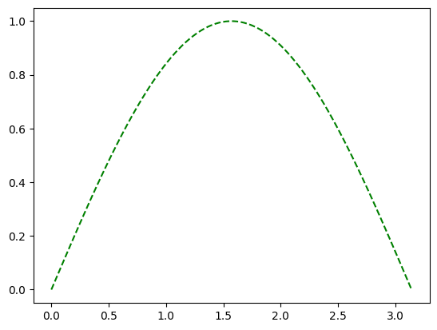

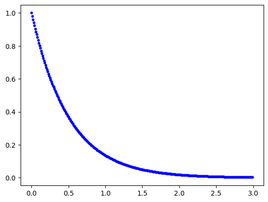

```python
# import
import matplotlib.pyplot as plt
import numpy as np

# basic plt.plot(): plotting sin(x), 100  x values from 0 to pi.
xs = np.linspace(0,np.pi,100)
ys = np.sin(xs)

R0=2
xS = np.arange(0,3,0.01) # Z = 0, 0.01, 0.02, ..., 0.99
yS = [np.exp(-R0*x) for x in xS] # Gives array of exponents of each val in xS

figure(1)
plt.plot(xs,ys, '--g')
figure(2)
plt.plot(xS,yS, '.b')

# Extra:
# plt.subplot(1, 2, 1) # row 1, col 2 index 1
# plt.plot(xs,ys, '--g')
# plt.subplot(1, 2, 2) # index 2
# plt.plot(xS, yS, '--r')
```

### Matrix rows, columns

Back to Top

```python
import numpy as np
A = np.array([[1, 2, 3], [4, 5, 6], [7, 8, 9]])
print(A[0]) # Prints row
print(A[:,0]) # Prints column
```

```
[1 2 3]
[1 4 7]
```

```python
# you can write a function that returns a function
def f(n):
    def g(x):
        return x**n
    return g
# Test
a = f(3) # returns a function g(x) that computes x**3
print(a(2))

# this can be rewritten as returning an lambda expression
def F(n):
    return lambda x: x**n
# Test
b = F(3) # returns x**3
print(b(2))


# or, even an rewritten as a lambda function returning a lambda function
F = lambda n: lambda x: x**n # Note: Taking n from previous code
# Test
c = F(3)
print(c(2))
print(F(3)(2)) # Since x is inner function, n outer, x^n, give n first then x
```

```
8
8
8
8
```

## Linear Algebra

Back to Top

### Solving linear systems

Back to Top

Solves $$ Ax = b $$

```python
# solve(a, b) solves ax = b
from numpy.linalg import solve

from numpy import array
A = array([[1,2,3], [2,2,3], [3,4,5]])
print(A) #Note that A must be square
b = array([6, 7, 12])
solve(A, b)
```

```
[[1 2 3]
 [2 2 3]
 [3 4 5]]
```

```
array([1., 1., 1.])
```

### Norm (magnitude) of a vector

Back to Top

+ p-norm: $$ ||x_p|| = (\sum_{i=1}^{n}|x_i|^p)^\frac{1}{p} $$

- **1-norm: **Sum of abs of each element of vector, if matrix sum abs columns & ret largest
- **2-norm:** Shortest distance to origin
- **inf-norm:** Abs of max element of vector, if matrix sum abs of rows, ret max

Used to compare vectors/matrices; Helpful for best fit

```python
from numpy import array as arr
from numpy.linalg import norm

a = ([[1,2,3],[4,5,6,],[7,8,9]])
print(norm(a, 1)) # Max col's, 3+6+9
print(norm(a)) # ?!
print(norm(a, np.inf)) # Max rows, 7+8+9
```

```
18.0
16.881943016134134
24.0
```

Back to Top

```python
# Ex: Nonlinear newton's method
# - norm(x) returns two-norm
# - norm(x, p) returns p-norm (max = inf)

from numpy.linalg import norm

# Use Newton's method to solve f(x)=0
# Df is the Jacobian matrix as a function of x (Matrix of partial derivatives)
# x0 is the initial guess
# epsilon gives the termination condition, i.e., ||f(x)||<epsilon
# maxiter: the maximum number of iterations allowed
# returns the solution as an array, and the number of iterations performed
def Newton(f, Df, x0, epsilon=1e-6, maxiter=1000):
    f0 = f(x0)
    for i in range(1, maxiter+1):
        h = solve(Df(x0), -f0)
        x1 = x0 + h
        f1 = f(x1)
        if norm(f1) < epsilon: # Want 'size' to be near 0, compare w epsilon
            break
        x0 = x1
        f0 = f1
    if i == maxiter:
        print("maximum number of iterations reached")
    return x0, i
```

Use to solve: $$ \begin{align} x^2 + y^2 = 2\\ xy = 1 \end{align} $$

```python
f = lambda xy: array([ # x[0] is x, x[1] is y
    x[0]**2 + x[1]**2 - 2,
    x[0]*x[1] - 1
])
Df = lambda x: array([
    [2*x[0], 2*x[1]],
    [x[1], x[0]]
])
x, iter = Newton(f, Df, x0=array([-1,-2]))
print("x=", x, "after", iter, "iterations")
print("f(x)=", f(x))
```

```
maximum number of iterations reached
x= [ 10.32222638 -65.21691816] after 1000 iterations
f(x)= [4357.79477187 -674.18379281]
```

### Polynomials

Back to Top

```python
from numpy.polynomial.polynomial import Polynomial

p = Polynomial([1,2,3])  # 3*x**2 + 2*x + 1
print(p)
```

```
1.0 + 2.0·x + 3.0·x²
```

### Vandermonde

Back to Top

```python
import numpy as np

x = np.array([0, 1, 2, 3])
A = np.zeros([4, 4])

for i in range(len(x)):
    for j in range(len(x)):
        A[i,j] = x[i]**j
print("A=", np.matrix(A))
```

```
A= [[ 1.  0.  0.  0.]
 [ 1.  1.  1.  1.]
 [ 1.  2.  4.  8.]
 [ 1.  3.  9. 27.]]
```

+ Reminder: Vandermonde

- V: X's
- a: Coefficients of polynomial
- p(x): y's

[figure not shown]

```
1.0 + 5.0·x - 3.0·x²
```

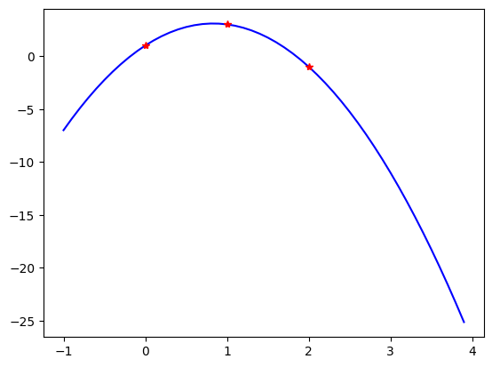

```python
# Find polynomial passing thru (0,1), (1,3), (2,-1);
# Take Vandemonde of x-coordinates,
# Vector of y-coordinates,
# Solve for c's

from matplotlib.pyplot import plot
from numpy.polynomial.polynomial import Polynomial

A = array([[1, 0, 0], [1, 1, 1], [1, 2, 4]])
b = array([1, 3, -1])
c = solve(A, b)
P = Polynomial(c)

from numpy import arange
x = arange(-1, 4, 0.1)
plot(x, P(x), '-b')
plot([0,1,2], [1, 3, -1], '*r')
print(P)
```

### Ex: Polynomial interpolation 2

Back to Top

Find the cubic polynomial that passes though $(0, 0)$, $(1, 2)$, $(2, -1)$ and $(3, 1)$, and find an intersection of the polynomial with with $y=1-x$

```
A= [[ 1.  0.  0.  0.]
 [ 1.  1.  1.  1.]
 [ 1.  2.  4.  8.]
 [ 1.  3.  9. 27.]]
a= [ 0.          7.83333333 -7.5         1.66666667]
0.0 + 7.83333333·x - 7.5·x² + 1.66666667·x³
Solution: x =  [0.12638975]  y =  [0.87361025]
```

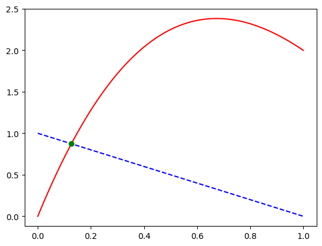

```python
from numpy.polynomial.polynomial import Polynomial
from scipy.optimize import fsolve
from numpy import zeros

# The coefficient matrix
x = array([0, 1, 2, 3])
y = array([0, 2, -1, 1])

A = zeros([4, 4])

# Create vandermonde *** HANDY
for i in range(len(x)):
    for j in range(len(x)):
        A[i,j] = x[i]**j
print("A=", A)
a = solve(A, y) # Gives polynomial solution
print("a=",a)

p = Polynomial(a)
print(p)
# Note: Exponents increase instead of std. decrease!!!

s = fsolve(lambda x: p(x)-(1-x), 0) # Solve for where equivalent
print("Solution: x = ", s, " y = ", 1-s)
# Plot the polynomial and the straight line to verify our answer
from numpy import linspace
from matplotlib.pyplot import plot
xx = linspace(0, 1, 100)
plot(xx, p(xx), "-r", xx, 1-xx, "--b", s, 1-s, "og")
```

### Ex: Polynomial interpolation function

Back to Top

... Denoting the Vandermonde matrix as $\text{V}$, we rearrange $\text{VA} = \text{Y}$ to solve for $\text{A}$, giving $\text{V}^{-1}\text{Y} = \text{A}$, the coefficients of the polynomial

```python
import numpy as np

# Supress scientific notation for matrix legibility
# np.set_printoptions(suppress=True)

def poly(x, y):
    # Create V^-1 from x values:
    n = len(x)
    v = np.array(np.ones((n, n)))
    for a in range(0, n):
        for i in range(1, n):
            v[a, i] = x[a]**i
    v = np.linalg.inv(v)

    # Return V^-1 * Y = A
    return np.matmul(v, y)
```

### EX: Linear Least Square Fitting, exponential growth rate

Back to Top

The number of COVID-19 cases $x(t)$ in BC from March 3rd to March 23rd are...

```
21 21
```

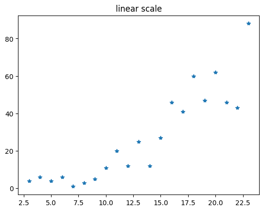

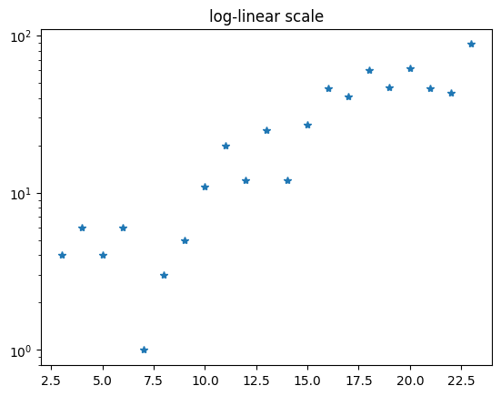

```python
from matplotlib.pyplot import plot, semilogy, figure, title
t = range(3, 24)
x = [4,6,4,6,1,3,5,11,20,12,25,12,27,46,41,60,47,62,46,43,88]

print(len(x), len(t))
figure(0)
plot(t, x, "*")
title("linear scale")
figure(1)
semilogy(t, x, "*")
title("log-linear scale")
```

We use the following formula and solve: $$ \left[\begin{array}{cc} \sum_{i=0}^nx_i^2 & \sum_{i=0}^nx_i\\ \sum_{i=0}^nx_i & n \end{array}\right] \left[\begin{array}{c} a \\ b \end{array}\right] = \left[\begin{array}{cc} \sum_{i=0}^nx_i y_i\\ \sum_{i=0}^ny_i \end{array}\right] $$

```
0.17650691194354481
[ 3  4  5  6  7  8  9 10 11 12 13 14 15 16 17 18 19 20 21 22 23]
```

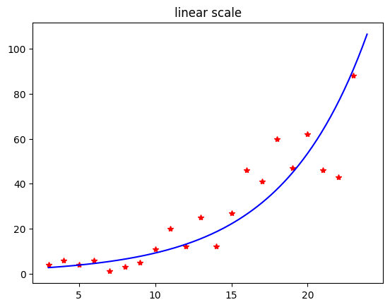

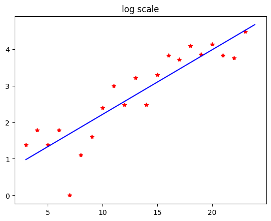

```python
from numpy import exp, log # the exp and log can take an array as input
x = arange(3, 24)
y = log([4,6,4,6,1,3,5,11,20,12,25,12,27,46,41,60,47,62,46,43,88])

A = array([[sum(x*x), sum(x)], [sum(x), len(x)]])
B = array([sum(x*y), sum(y)])
[a, b] = solve(A, B)
# ^ Saves each element of solution as individual variable
print(a)
print(x)

t = arange(3, 24, 0.1)
figure(0)
plot(x, exp(y), '*r')
plot(t, exp(t*a+b), '-b')
title("linear scale")
figure(1)
plot(x, y, '*r')
plot(t, t*a+b, '-b') # Note use of t*a+x
title("log scale")
```

### Eigenvectors/values

Back to Top

```python
import numpy as np
A = np.array([[1, 2, 3], [4, 5, 6], [7, 8, 9]])

evl, evt = eig(A)

print(evl)
print(evt) # Note: nth column corresponds to nth eigenvalue!
           # Must use [:,n] to print accordingly
```

```
[ 1.61168440e+01 -1.11684397e+00 -1.30367773e-15]
[[-0.23197069 -0.78583024  0.40824829]
 [-0.52532209 -0.08675134 -0.81649658]
 [-0.8186735   0.61232756  0.40824829]]
```

### Ex: Find eigenvectors, values of matrix

Back to Top

$$ \left[\begin{array}{cc} 0.5 & 0.3 & 0\\ 0.3 & 0.3 & 0.4\\ 0.2 & 0.4 & 0.6 \\ \end{array}\right] $$

+ For method 2: Solve $$ \begin{align} 0.5x+0.3y & =x\\ 0.3x+0.3y +0.4z & =y\\ 0.2x + 0.4y + 0.6z &=z\\ x+y+z & =1 \end{align} $$

```python
from numpy.linalg import solve, eig
from numpy import array

# Method 1: Direct
A = array([[0.5, 0.3, 0], [0.3, 0.3, 0.4], [0.2, 0.4, 0.6]])
print(np.matrix(A)) # Handy
evalue, evect = eig(A)
print("The eigenvector associated with the eigenvalue ", evalue[0], " is ", evect[:,0])

# Method 2: Solve using system of linear eqn's ;
# Rewrite as Ax = b, noting that eqn's are dependant (choose 3/4) & solve
# We pick the second and third equations...
A = array([[0.3, -0.7, 0.4], [0.2, 0.4, -0.4], [1, 1, 1]])
b = array([0, 0, 1])
solve(A, b)
```

```
[[0.5 0.3 0. ]
 [0.3 0.3 0.4]
 [0.2 0.4 0.6]]
The eigenvector associated with the eigenvalue  0.9999999999999997  is  [-0.343559   -0.57259833 -0.74437783]
```

```
array([0.20689655, 0.34482759, 0.44827586])
```

### Ex: Primary component analysis, height-weight

Back to Top

Using height/weight data from 200 samples, find a linear combination of variables (variable change) that 'explains' (?) variance in data

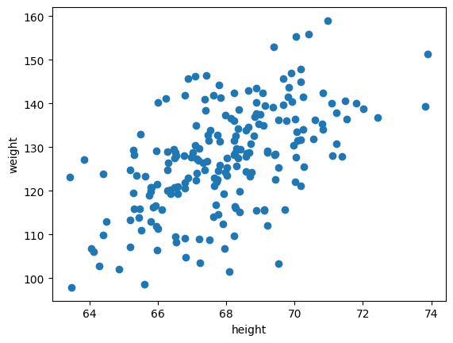

```python
# Scatterplot
import matplotlib.pyplot as plt

height = array([65.78, 71.52, 69.4, 68.22, 67.79, 68.7, 69.8, 70.01, 67.9, 66.78, 66.49, 67.62, 68.3, 67.12, 68.28, 71.09, 66.46, 68.65, 71.23, 67.13, 67.83, 68.88, 63.48, 68.42, 67.63, 67.21, 70.84, 67.49, 66.53, 65.44, 69.52, 65.81, 67.82, 70.6, 71.8, 69.21, 66.8, 67.66, 67.81, 64.05, 68.57, 65.18, 69.66, 67.97, 65.98, 68.67, 66.88, 67.7, 69.82, 69.09, 69.91, 67.33, 70.27, 69.1, 65.38, 70.18, 70.41, 66.54, 66.36, 67.54, 66.5, 69, 68.3, 67.01, 70.81, 68.22, 69.06, 67.73, 67.22, 67.37, 65.27, 70.84, 69.92, 64.29, 68.25, 66.36, 68.36, 65.48, 69.72, 67.73, 68.64, 66.78, 70.05, 66.28, 69.2, 69.13, 67.36, 70.09, 70.18, 68.23, 68.13, 70.24, 71.49, 69.2, 70.06, 70.56, 66.29, 63.43, 66.77, 68.89, 64.87, 67.09, 68.35, 65.61, 67.76, 68.02, 67.66, 66.31, 69.44, 63.84, 67.72, 70.05, 70.19, 65.95, 70.01, 68.61, 68.81, 69.76, 65.46, 68.83, 65.8, 67.21, 69.42, 68.94, 67.94, 65.63, 66.5, 67.93, 68.89, 70.24, 68.27, 71.23, 69.1, 64.4, 71.1, 68.22, 65.92, 67.44, 73.9, 69.98, 69.52, 65.18, 68.01, 68.34, 65.18, 68.26, 68.57, 64.5, 68.71, 68.89, 69.54, 67.4, 66.48, 66.01, 72.44, 64.13, 70.98, 67.5, 72.02, 65.31, 67.08, 64.39, 69.37, 68.38, 65.31, 67.14, 68.39, 66.29, 67.19, 65.99, 69.43, 67.97, 67.76, 65.28, 73.83, 66.81, 66.89, 65.74, 65.98, 66.58, 67.11, 65.87, 66.78, 68.74, 66.23, 65.96, 68.58, 66.59, 66.97, 68.08, 70.19, 65.52, 67.46, 67.41, 69.66, 65.8, 66.11, 68.24, 68.02, 71.39])
weight = array([112.99, 136.49, 153.03, 142.34, 144.3, 123.3, 141.49, 136.46, 112.37, 120.67, 127.45, 114.14, 125.61, 122.46, 116.09, 140, 129.5, 142.97, 137.9, 124.04, 141.28, 143.54, 97.9, 129.5, 141.85, 129.72, 142.42, 131.55, 108.33, 113.89, 103.3, 120.75, 125.79, 136.22, 140.1, 128.75, 141.8, 121.23, 131.35, 106.71, 124.36, 124.86, 139.67, 137.37, 106.45, 128.76, 145.68, 116.82, 143.62, 134.93, 147.02, 126.33, 125.48, 115.71, 123.49, 147.89, 155.9, 128.07, 119.37, 133.81, 128.73, 137.55, 129.76, 128.82, 135.32, 109.61, 142.47, 132.75, 103.53, 124.73, 129.31, 134.02, 140.4, 102.84, 128.52, 120.3, 138.6, 132.96, 115.62, 122.52, 134.63, 121.9, 155.38, 128.94, 129.1, 139.47, 140.89, 131.59, 121.12, 131.51, 136.55, 141.49, 140.61, 112.14, 133.46, 131.8, 120.03, 123.1, 128.14, 115.48, 102.09, 130.35, 134.18, 98.64, 114.56, 123.49, 123.05, 126.48, 128.42, 127.19, 122.06, 127.61, 131.64, 111.9, 122.04, 128.55, 132.68, 136.06, 115.94, 136.9, 119.88, 109.01, 128.27, 135.29, 106.86, 123.29, 109.51, 119.31, 140.24, 133.98, 132.58, 130.7, 115.56, 123.79, 128.14, 135.96, 116.63, 126.82, 151.39, 130.4, 136.21, 113.4, 125.33, 127.58, 107.16, 116.46, 133.84, 112.89, 130.76, 137.76, 125.4, 138.47, 120.82, 140.15, 136.74, 106.11, 158.96, 108.79, 138.78, 115.91, 146.29, 109.88, 139.05, 119.9, 128.31, 127.24, 115.23, 124.8, 126.95, 111.27, 122.61, 124.21, 124.65, 119.52, 139.3, 104.83, 123.04, 118.89, 121.49, 119.25, 135.02, 116.23, 109.17, 124.22, 141.16, 129.15, 127.87, 120.92, 127.65, 101.47, 144.99, 110.95, 132.86, 146.34, 145.59, 120.84, 115.78, 128.3, 127.47, 127.88])

plt.plot(height, weight, "o")
plt.xlabel("height")
plt.ylabel("weight")
```

+ Review: Varince, Covarince

\begin{align} \text{Var}[W] & =\frac{1}{n-1}\sum_{i=1}^n(w_i-\bar w)^2\\ \text{Var}[H] & =\frac{1}{n-1}\sum_{i=1}^n(h_i-\bar h)^2\\ \text{Cov}(W,H) & =\frac{1}{n-1}\sum_{i=1}^n(w_i-\bar w)(h_i-\bar h) \end{align} where $\bar w$ and $\bar h$ are the sample mean \begin{align} \bar w &= \frac{1}{n}\sum_{i=1}^n w_i\\ \bar h &= \frac{1}{n}\sum_{i=1}^n h_i \end{align}

#### Primary component

$$ U=\alpha W + \beta H $$

#### Secondary component

$$ V=\gamma W + \delta H $$ where $\left[\begin{array}{c}\gamma\\ \delta\end{array}\right]$ is the eigenvector associated with the second largest eigenvalue

#### Relate to variance

If $U$ represents the linear relationship between height and weight, then $V$ represents the deviation from this relationship - can be used as a body weight index. Make a scatter plot for $U$ and $V$.

Back to Top

Back to Top

Back to Top

```
[[143.06454442  12.92404964]
 [ 12.92404964   3.76500699]]
eigenvalues= [144.25347516   2.57607625]
eigenvectors=
 [[ 0.99579525 -0.09160686]
 [ 0.09160686  0.99579525]]

Primary component U =  0.9957952517587229 W +  0.09160685877586798 H
Secondary component V =  -0.09160685877586798 W +  0.9957952517587229 H
```

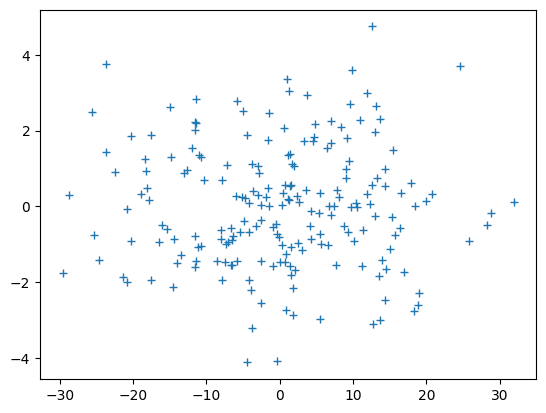

```python
from numpy import matmul, mean
from numpy.linalg import eig

n = len(weight)
# 1. Shift to zero-mean
X = array([weight-mean(weight), height-mean(height)]).T
# 2. The variance and covariance matrix
VCov = matmul(X.T, X)/(n-1)
print(VCov)
# 3. Eigenvalues and eigenvectors
e, P = eig(VCov)
print("eigenvalues=", e)
print("eigenvectors=\n",P)
print()
print("Primary component U = ", P[0][0], "W + ", P[1][0], "H")
print("Secondary component V = ", P[0][1], "W + ", P[1][1], "H")


# Scatterplot
from numpy import linspace
alpha = P[0,0]
beta=P[1,0]
gamma = P[0,1]
delta = P[1,1]
U = alpha*X[:,0]+beta*X[:,1]
V = gamma*X[:,0]+delta*X[:,1]
# Alternatively U, V are the two columns of the matrix product XP
# Y=matmul(X, P)
# U = Y[:,0]
# V = Y[:,1]
plot(U, V,"+")
```

### Matrix transpose

Back to Top

```python
import numpy as np
A = np.array([[1,2,3],[4,5,6]])
print(A)
print("A.T=\n", A.T) # Instance variable
print("A.transpose()=\n", A.transpose()) # Method
print("numpy.transpose(A)=\n", np.transpose(A)) # Function
```

```
[[1 2 3]
 [4 5 6]]
A.T=
 [[1 4]
 [2 5]
 [3 6]]
A.transpose()=
 [[1 4]
 [2 5]
 [3 6]]
numpy.transpose(A)=
 [[1 4]
 [2 5]
 [3 6]]
```

### Matrix products

Back to Top

```python
import numpy as np
A = np.array([[1,2,3],[4,5,6]])

# Element-wise/hadamard product: C = A*B <-> Cij = Aij * Bij
print(A*A)

# Marix product, req's col(A) = row(B)
print(np.matmul(A, A.T))
print(np.matmul(A.T, A))
```

```
[[ 1  4  9]
 [16 25 36]]
[[14 32]
 [32 77]]
[[17 22 27]
 [22 29 36]
 [27 36 45]]
```

### Ex: Linear regression using matrix product

Back to Top

Let $$X=\left[\begin{array}{cc} x_0 & 1\\ x_1 & 1\\ \vdots & \vdots\\ x_n & 1 \end{array}\right],\; Y=\left[\begin{array}{c} y_0\\ y_1\\ \vdots\\ y_n \end{array}\right],\;$$ Then the linear regression formula can be written as $$X^TX \left[\begin{array}{c} a \\ b \end{array}\right]=X^TY$$

```
[ 3  4  5  6  7  8  9 10 11 12 13 14 15 16 17 18 19 20 21 22 23]
[1.38629436 1.79175947 1.38629436 1.79175947 0.         1.09861229
 1.60943791 2.39789527 2.99573227 2.48490665 3.21887582 2.48490665
 3.29583687 3.8286414  3.71357207 4.09434456 3.8501476  4.12713439
 3.8286414  3.76120012 4.47733681]
[[ 3.  1.]
 [ 4.  1.]
 [ 5.  1.]
 [ 6.  1.]
 [ 7.  1.]
 [ 8.  1.]
 [ 9.  1.]
 [10.  1.]
 [11.  1.]
 [12.  1.]
 [13.  1.]
 [14.  1.]
 [15.  1.]
 [16.  1.]
 [17.  1.]
 [18.  1.]
 [19.  1.]
 [20.  1.]
 [21.  1.]
 [22.  1.]
 [23.  1.]]
0.17650691194354498 0.44937822746870165
```

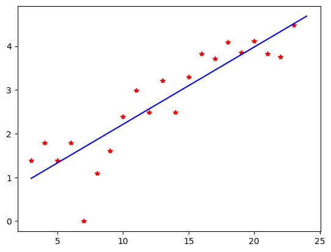

```python
# linear regression using matrix product
import numpy as np

# Data
x = np.arange(3, 24)
y = np.log([4,6,4,6,1,3,5,11,20,12,25,12,27,46,41,60,47,62,46,43,88])
print(x)
print(y)

# Construct X
X = np.array([x, np.ones(len(x))]).T
print(X)

[a, b] = np.linalg.solve(np.matmul(X.T, X), np.matmul(X.T, y))
print(a, b)

t = np.linspace(3, 24, 100)
from matplotlib.pyplot import plot
plot(x, y, '*r', t, t*a+b, '-b') # Element-wise product & summation
```

### Inverse matrix

Back to Top

```python
from numpy import matmul
from numpy.linalg import inv

A = array([[1, 2, 3], [2, 2, 3], [2, 3, 4]])
print("inv(A)=\n", inv(A))
```

```
inv(A)=
 [[-1.  1.  0.]
 [-2. -2.  3.]
 [ 2.  1. -2.]]
```

### Ex: Solving multiple of linear system w same coefficient matrix using inverse

Back to Top

Solve $$ \left[\begin{array}{ccc}1 & 2 & 3\\ 2 & 2 & 3\\ 2 & 3 & 4\end{array}\right]X = \left[\begin{array}{ccc}1 & 2 & 3 &4\\ -1 & -2 & -3 & -4\\ 0 & 0 & 0 & 0\end{array}\right] $$

Then $$ X = \left[\begin{array}{ccc}1 & 2 & 3\\ 2 & 2 & 3\\ 2 & 3 & 4\end{array}\right]^{-1} \left[\begin{array}{ccc}1 & 2 & 3 &4\\ -1 & -2 & -3 & -4\\ 0 & 0 & 0 & 0\end{array}\right] $$

```python
from numpy import matmul
from numpy.linalg import inv

A = array([[1, 2, 3], [2, 2, 3], [2, 3, 4]])
B = array([[1, 2, 3, 4], [-1, -2, -3, -4], [0, 0, 0, 0]])
print("inv(A)=\n", inv(A))
print("X=\n", matmul(inv(A), B))
```

```
inv(A)=
 [[-1.  1.  0.]
 [-2. -2.  3.]
 [ 2.  1. -2.]]
X=
 [[-2. -4. -6. -8.]
 [ 0.  0.  0.  0.]
 [ 1.  2.  3.  4.]]
```

### Change coordinate systems

Back to Top

Given coordinates under $E = \{e_i\}$ (Std. basis) $x = {x_1, \dots, x_n}$, coordinates under $V$ $y = {y_1, \dots, y_n}$, where $P = \{\vec{v_i}\}_{i=1}^n$ is a set of basis of $\mathbb{R}^n$, use following to change coordinates:

$$ x = \sum_{i=1}^n y_i\vec{v_i} = [P]y \Leftrightarrow y=[P]^{-1}x $$

### Ex: Change coordinate systems

Back to Top

+ **Ex:** A free falling object has a trajectory \begin{align} x(t) & = 2t\\ y(t) & = -4.9t^2+t+1 \end{align} A video camera tilted 15 degree counter clockwise focused at the origin captured the trajectory for the period $t\in[0,0.5]$. What does the trajectory look like on the video?

- In the video, the The horizontal axis and the vertical axis of the camera points at $$\left[\begin{array}{c}\cos\frac{\pi}{12}\\\sin\frac{\pi}{12}\end{array}\right],\; \left[\begin{array}{c}-\sin\frac{\pi}{12}\\\cos\frac{\pi}{12}\end{array}\right]$$

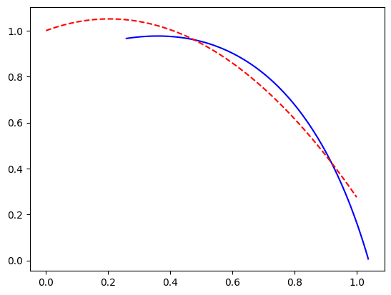

```python
from math import pi
from numpy import zeros, linspace, sin, cos, array, matmul
from numpy.linalg import inv

## Here we use the sin and cos function from numpy.
## The main advantage of these over math.sin and math.cos is that
## they can take a list as input, and apply the function to each element in the list

P = array([[cos(pi/12), -sin(pi/12)], [sin(pi/12), cos(pi/12)]])

# we plot the trajectory for the time points t=0, 0.01, 0.02, ..., 0.5
t = linspace(0, 0.5, 101) # from 0 to 0.5,101 points.

# we create the true trajectory in a matrix,
# with each column corresponding to a point on the trajectory
T = array([2*t, -4.9*t**2 + t + 1])

# the trajectory in the video is
V = matmul(inv(P), T)

from matplotlib.pyplot import plot
plot(V[0], V[1], '-b', T[0], T[1], '--r')
```

### Ex2: Change coordinate system, lab Oct.12

Back to Top

1. Plot the parabola $y=x^2+x-2$ for $x\in[-2,1]$ under $$ v_1 = \left[\begin{array}{cc}1\\2\end{array}\right],\; v_2 = \left[\begin{array}{cc}-1\\2\end{array}\right] $$

The points on the parabola are $(x, x^2+x-2)$, and $$ \left[\begin{array}{cc}u_1\\u_2\end{array}\right]=P^{-1} \left[\begin{array}{cc}x\\y\end{array}\right],\;\text{ where } P=[v_1, v_2] $$

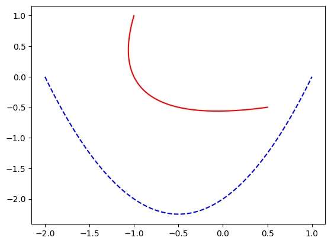

```python
import numpy as np
import matplotlib.pyplot as plt

x = np.linspace(-2, 1, 100)
y = x**2 + x - 2
# the parabola in xy coordinates is plotted as a dashed blue curve
plt.plot(x, y, '--b')

P = np.array([[1, -1], [2, 2]])
# Put the coordinates into a matrix
XY = np.array([x, y])
# variable change

from numpy.linalg import inv
U = np.matmul(inv(P), XY)
# the coordiantes are in the first and second rows of U
u1 = U[0]
u2 = U[1]
# the parabola in u1 u2 coordinates  is plotted as a red curve
plt.plot(u1, u2, '-r')
```

Shift origin of new coordinates system to xy plane

$$\left[\begin{array}{c}x\\y\end{array}\right] = u_1\vec v_1+u_2\vec v_2 + \left[\begin{array}{c}x_0\\y_0\end{array}\right] = P\left[\begin{array}{c}u_1\\u_2\end{array}\right]+\left[\begin{array}{c}x_0\\y_0\end{array}\right]$$ where $P=[\vec v_1,\vec v_2]$

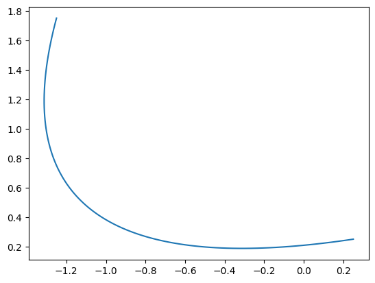

```python
# Shift origin to (1, -1); (x0, y0)

XY = np.array([x-1, y-(-1)])

from numpy.linalg import inv
U = np.matmul(inv(P), XY)
# the coordiantes are in the first and second rows of U
u1 = U[0]
u2 = U[1]
# the parabola in u1 u2 coordinates  is plotted as a red curve
plt.plot(u1, u2)
```

### Ex: Graph shape in coordinate system under regular coordinates

Back to Top

Use $\left[\begin{array}{cc}x\\y\end{array}\right] = P \left[\begin{array}{cc}u_1\\u_2\end{array}\right]$, where $P=[v_1, v_2]$ is the given coordinate system

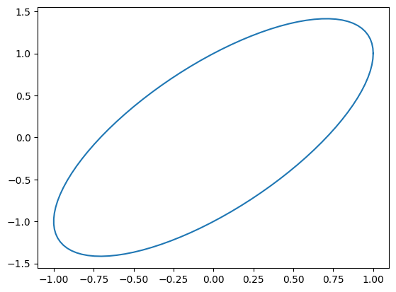

```python
from numpy import pi, sin, cos, linspace, matmul
from matplotlib.pyplot import plot
import numpy as np

# Parametrize
theta = linspace(0, 2*pi, 100)
u1 = cos(theta)
u2 = sin(theta)

# Define p, u, xy
p = np.array([[1, 0], [1, 1]])
u = np.array([u1, u2])
xy = matmul(p, u)

plot(xy[0,:],xy[1,:])
```

### Diagonalization

Back to Top

If $A_{n\times n}$ has $n$ distinct eigenvalues, is diagonalizable.

- Let $P$ be matrix of eigenvectors
- $D = diag{\lambda_1, \dots, \lambda_n}$

Then $$ A = PDP^-1 $$

+ Note: $y = P^{-1}x$ is coordinates change from std. basis $E$ to basis $P$ of eigenvectors of $A$, so that under basis $P$ the coordinate of $Ax$ is $$ P^{-1}Ax = P^{-1}PDP^{-1}x = DP^{-1}x = Dy $$

### Example: Diagonalization, double/half along direction

Back to Top

Find the matrix which doubles along the direction $v_1=[-1, 2]^T$ and shrinks by half along the direction $[2,1]^T$ perpendicular to $v_1$.

```python
from numpy import array, matmul
from numpy.linalg import inv
P = array([[-1, 2], [2, 1]])
D = array([[2, 0], [0, 0.5]])
print("P=\n", P)
print("D=\n", D)
A = matmul(matmul(P, D), inv(P))
print("A=\n", A)
```

```
P=
 [[-1  2]
 [ 2  1]]
D=
 [[2.  0. ]
 [0.  0.5]]
A=
 [[ 0.8 -0.6]
 [-0.6  1.7]]
```

### Spectral radius

Back to Top

```python
from numpy import abs
from numpy.linalg import eig
import numpy as np

def spectralRadius(A):
    e, P = eig(A)
    return max(abs(e))

A = np.array([[1,1],[-1,1]])
print(A)
e, P = eig(A)
print(e)
spectralRadius(A)
```

```
[[ 1  1]
 [-1  1]]
[1.+1.j 1.-1.j]
```

```
1.4142135623730951
```

## Plotting

Back to Top

### The `plot` function

Back to Top

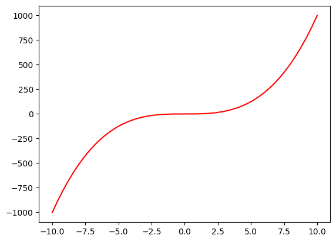

```python
# Takes x coordinates, y coordinates, line specification
# Returns .Line2D object representing each line/point
import numpy as np
import matplotlib.pyplot as plt

xs = np.linspace(-10, 10, 51)
ys = [x**3 for x in xs]

plt.plot(xs, ys, '-r')
```

### Adjusting axis

Back to Top

```
(-10.0, 10.0, -10.0, 10.0)
```

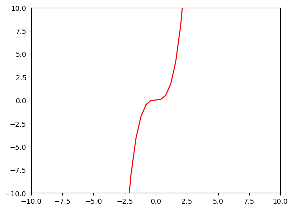

```python
# axis function, 3 use cases:
# xmin, xmax, ymin, ymax = axis() returns x,y limits of axis
# axis(xmin, xmax, ymin, ymax) sets x,y lims of axis
# axis(<on/off>) turns axis on or off
# help(axis) for other use cases

import numpy as np
import matplotlib.pyplot as plt

xs = np.linspace(-10, 10, 51)
ys = [x**3 for x in xs]

plt.plot(xs, ys, '-r')
plt.axis([-10, 10, -10, 10])
```

### Animation

Back to Top

[video not shown]

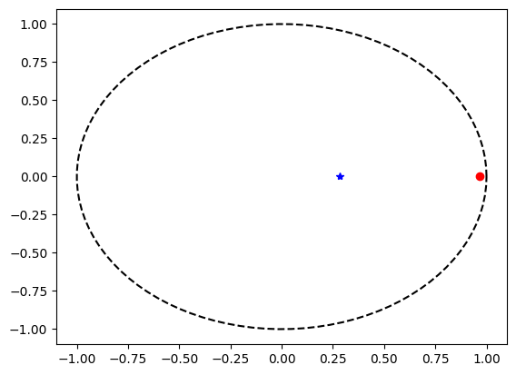

```python
from IPython.display import HTML
from matplotlib.animation import FuncAnimation
from matplotlib.pyplot import *
import numpy as np

# ...
gamma = 0.25
sigma = 0.5
J = lambda beta: np.array([[1-sigma, beta], [sigma, 1-gamma]])

t = np.linspace(0, 2*pi, 100)

# create figure
fig = figure()

# plot curves
points = plot(np.cos(t), np.sin(t), '--k', [], [], "b*", [], [], "ro")

def update(beta):
    e, P = np.linalg.eig(J(beta))
    # update the coordinates of each point on the complex plane
    points[1].set_data([np.real(e[0])], [np.imag(e[0])])
    points[2].set_data([np.real(e[1])], [np.imag(e[1])])

anim = FuncAnimation(fig, update, frames=np.linspace(0.2, 0.3, 11))

HTML(anim.to_html5_video())
```

### Ex: Animating SIR curve as $\beta$ changes

Back to Top

[video not shown]

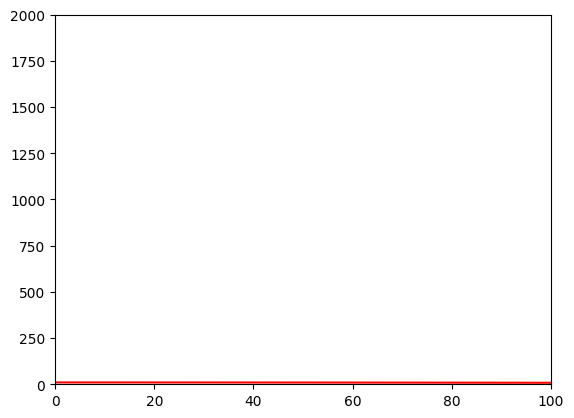

```python
import numpy as np
from matplotlib.pyplot import *
from matplotlib.animation import FuncAnimation
from IPython.display import HTML

def SIR(times, I0, beta, gamma, N):
    # create the matrix
    V = np.zeros((len(times), 3))
    # the initial condition is the first row
    S = N-I0
    I = I0
    R = 0
    V[0] = [S, I, R]
    # for each successive time point, compute the number of infections and recoveries
    # and compute the S, I and R
    for t in range(1,len(times)):
        infections = beta * S * I / N
        recoveries = gamma * I
        S = S - infections
        I = I + infections - recoveries
        R = R + recoveries
        V[t] = [S, I, R]
    return V

gamma, N, I0 = 0.2, 10000, 10

t = range(0, 101)
b = np.linspace(0.2, 0.4, 11)
#V = lambda b: SIR(t, I0, b, gamma, N)
# axis([None, 100, None, None])

# for b in np.arange(0.2, 0.4, 0.02):
#     plot(t, SIR(t, I0, b, gamma, N)[:,1], '-r')

fig = figure()

point = plot([], [], "-r")
axis([None, 100, None, 2000])

# y = lambda b: SIR(t, I0, b, gamma, N)[:,1]

## create the update function
## it takes the frame, here the time, as the input a, b, c, d
##
# def update(b):
#     point[0].set_data(t, y(b))

def update(b):
    point[0].set_data(t, SIR(t, I0, b, gamma, N)[:,1])

anim = FuncAnimation(fig, update, frames=b)
HTML(anim.to_html5_video())
```

### Ex: Animating a dot circling a curve

Back to Top

[video not shown]

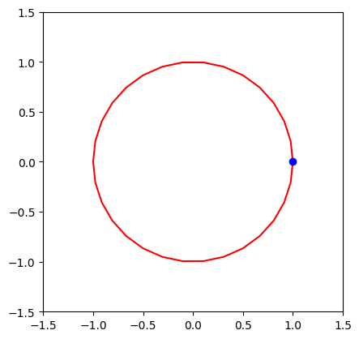

```python
# Solution
import matplotlib.pyplot as plt
import numpy as np
from matplotlib.animation import FuncAnimation
from IPython.display import HTML

fig, ax = plt.subplots()
plt.xlim(-1.5,1.5)
plt.ylim(-1.5,1.5)
ax.set_aspect(1)

xs = lambda x: np.cos(x)
ys = lambda y: np.sin(y)

a = np.linspace(0, 2*np.pi, 31)

x = xs(a)
y = ys(a)

# Plot line
plt.plot(x, y, "r")

# Create line2d object
point, = plt.plot(x, y, "ob")

# Update for line2d object
def update(frame):
    point.set_data([x[frame]], [y[frame]])

# Animate
anim = FuncAnimation(fig, update, frames=len(a))
HTML(anim.to_html5_video())
```

## Reading data

Back to Top

+ Note: Best/easiest to use pandas

### Opening a file

Back to Top

```python
# open(filename, mode)
# filename: String containing path to file
# mode: see help, default read (r)

f = open("transition.csv")
for l in f:
    # here l is a string
    print(l)
# remember to close
f.close()
```

```
1,2,0.5

1,3,0.5

2,1,0.8

2,3,0.2

3,1,1.0
```

### Alternative: `with` statement

Back to Top

```python
with open("transition.csv") as f:
    for l in f:
        print(l)
# we do not need to call f.close(), as it is called automatically when exiting
# the with statement
```

```
1,2,0.5

1,3,0.5

2,1,0.8

2,3,0.2

3,1,1.0
```

```python
# another example for the with statement
class Test:
    def __init__(self, name):
        self.name = name
    def __enter__(self):
        print("entered", self.name)
        return self
    def __exit__(self, exc_type, exc_value, traceback):
        print("left", self.name)

with Test("a") as a:
    print(a.name)
    # pass # pass means do nothing
```

```
entered a
a
left a
```

### `split`

Back to Top

```python
with open("transition.csv") as f: # Not subscriptable
    for l in f:
        fields = l.split(",")
        print(int(fields[0]), int(fields[1]), float(fields[2]))
# we do not need to call f.close(), as it is called automatically when exiting
# the with statement
```

```
1 2 0.5
1 3 0.5
2 1 0.8
2 3 0.2
3 1 1.0
```

### `csv` module - reader

Back to Top

```python
# Takes file object as first arg,
# optional keywords incl. delimiter="x", quotechar="x"(surrounds delimited items)

from csv import reader
with open("transition.csv") as f:
    table = reader(f) # Not subscriptable
    for l in table:
        print(int(l[0]), int(l[1]), float(l[2]))
```

```
1 2 0.5
1 3 0.5
2 1 0.8
2 3 0.2
3 1 1.0
```

### Dictionaries

Back to Top

```python
# Used to associate val's to names
d = {"a":1, "b":"2"}
print(d)
print("d['a']=", d["a"])
print("d['b']=", d["b"])
# print("d['c']=", d["c"])

# Check if key is in dictionary
print("'a' in d =", "a" in d)
print("'c' in d =", "c" in d)

# Show, loop thru all available keys
keys = d.keys()
print(keys)

# Convert the keys to a list to access by index
ks = list(keys)
print(ks[0], ks[1])

# Loop through the keys
for key in keys:
    print(key)

# Loop through the dictionary
for key in d:
    print(key, d[key])

# Add, edit key-value pair
d["c"] = 3
print(d)
d["c"] = 4
print(d)

# pop
d["a"]=1
print(d.pop("a"))
print(d)

# Merge dictionaries
b = {"1":1}
d.update(b)
print(d)
```

```
{'a': 1, 'b': '2'}
d['a']= 1
d['b']= 2
'a' in d = True
'c' in d = False
dict_keys(['a', 'b'])
a b
a
b
a 1
b 2
{'a': 1, 'b': '2', 'c': 3}
{'a': 1, 'b': '2', 'c': 4}
1
{'b': '2', 'c': 4}
{'b': '2', 'c': 4, '1': 1}
```

### `DictReader`

Back to Top

```python
# Takes in file as first arg,
# takes `fieldames=["x", "y", ...]` as second
# If fieldnames not spec'd, uses fields in first row as names
from csv import DictReader
with open("transition.csv") as f:
    data = DictReader(f, fieldnames=["from", "to", "probability"])
    for record in data:
        print(record)
        print(int(record["from"]), int(record["to"]), float(record["probability"]))

print("without fieldnames")
with open("transition.csv") as f:
    data = DictReader(f)
    for record in data:
        print(record)
```

```
{'from': '1', 'to': '2', 'probability': '0.5'}
1 2 0.5
{'from': '1', 'to': '3', 'probability': '0.5'}
1 3 0.5
{'from': '2', 'to': '1', 'probability': '0.8'}
2 1 0.8
{'from': '2', 'to': '3', 'probability': '0.2'}
2 3 0.2
{'from': '3', 'to': '1', 'probability': '1.0'}
3 1 1.0
without fieldnames
{'1': '1', '2': '3', '0.5': '0.5'}
{'1': '2', '2': '1', '0.5': '0.8'}
{'1': '2', '2': '3', '0.5': '0.2'}
{'1': '3', '2': '1', '0.5': '1.0'}
```

### Best method: Pandas

Back to Top

```python
import numpy as np
import pandas as pd

# NO HEADERS:
# Use pandas to convert data into list
data = pd.read_csv('transition.csv', header=None) #Is a dataframe object
# Use iloc to locate by i
ds = data.iloc[:, 0] # Retrieves first column as dataframe object
a = ds.to_numpy() # To numpy array
ls = ds.tolist()
print(a, ls)

# HEADERS:
dataa = pd.read_csv('transitionHeader.csv')
d1, d2, d3 = dataa.n, dataa.i, dataa.p # By column header
l1, l2, l3 = d1.tolist(), d2.tolist(), d3.tolist()
print(l1, l2, l3)

#-----------------------------------------------------------

# Rows
for index, row in dataa.iterrows():
    print(row.n, row.i, row.p) # With headers
    print(row.iloc[0], row.iloc[1], row.iloc[2]) # Without headers

# Delimiter
dta = pd.read_csv('transition.csv', delimiter = '.', header=None)
print(dta) # Note: Reads delimiter as '.', creating 2 columns: A list & a num
```

```
[1 1 2 2 3] [1, 1, 2, 2, 3]
[1, 1, 2, 2, 3] [2, 3, 1, 3, 1] [0.5, 0.5, 0.8, 0.2, 1.0]
1.0 2.0 0.5
1.0 2.0 0.5
1.0 3.0 0.5
1.0 3.0 0.5
2.0 1.0 0.8
2.0 1.0 0.8
2.0 3.0 0.2
2.0 3.0 0.2
3.0 1.0 1.0
3.0 1.0 1.0
       0  1
0  1,2,0  5
1  1,3,0  5
2  2,1,0  8
3  2,3,0  2
4  3,1,1  0
```

### DataFrame object

Back to Top

```python
import pandas

# Create dataframe
data = pandas.DataFrame({
    "i":[1,1,2,2,3],
    "j":[2,3,1,3,1],
    "probability":[0.5,0.5,0.8,0.2,1.0]
})
display(data)

# Col's
print(data.probability)
print(1-data["probability"][2])
display(data[["i","j"]]) # Multiple

# Rows
display(data.head(3))
display(data.tail(3))
display(data[2:4]) # Range of rows
display(data[data.probability<=0.5]) # Pick

# Add column
data["comment"] = list(map(lambda i,j:str(i)+"->"+str(j), data.i, data.j))
display(data)

# Concat (Add row)
row = pandas.DataFrame({"i":[1],"j":[2],"probability": [3], "comment":"new"})
new = pandas.concat((data, row))
print(data) # the original data is unchanged
display(new)

# Remove row
data.drop([2,3])

# Remove col
data.drop(columns=["comment"])

# Convert to matrix
data[["i","j"]].values
```

|  | i | j | probability |
| --- | --- | --- | --- |
| 0 | 1 | 2 | 0.5 |
| 1 | 1 | 3 | 0.5 |
| 2 | 2 | 1 | 0.8 |
| 3 | 2 | 3 | 0.2 |
| 4 | 3 | 1 | 1.0 |

```
0    0.5
1    0.5
2    0.8
3    0.2
4    1.0
Name: probability, dtype: float64
0.19999999999999996
```

|  | i | j |
| --- | --- | --- |
| 0 | 1 | 2 |
| 1 | 1 | 3 |
| 2 | 2 | 1 |
| 3 | 2 | 3 |
| 4 | 3 | 1 |

|  | i | j | probability |
| --- | --- | --- | --- |
| 0 | 1 | 2 | 0.5 |
| 1 | 1 | 3 | 0.5 |
| 2 | 2 | 1 | 0.8 |

|  | i | j | probability |
| --- | --- | --- | --- |
| 2 | 2 | 1 | 0.8 |
| 3 | 2 | 3 | 0.2 |
| 4 | 3 | 1 | 1.0 |

|  | i | j | probability |
| --- | --- | --- | --- |
| 2 | 2 | 1 | 0.8 |
| 3 | 2 | 3 | 0.2 |

|  | i | j | probability |
| --- | --- | --- | --- |
| 0 | 1 | 2 | 0.5 |
| 1 | 1 | 3 | 0.5 |
| 3 | 2 | 3 | 0.2 |

|  | i | j | probability | comment |
| --- | --- | --- | --- | --- |
| 0 | 1 | 2 | 0.5 | 1->2 |
| 1 | 1 | 3 | 0.5 | 1->3 |
| 2 | 2 | 1 | 0.8 | 2->1 |
| 3 | 2 | 3 | 0.2 | 2->3 |
| 4 | 3 | 1 | 1.0 | 3->1 |

```
   i  j  probability comment
0  1  2          0.5    1->2
1  1  3          0.5    1->3
2  2  1          0.8    2->1
3  2  3          0.2    2->3
4  3  1          1.0    3->1
```

|  | i | j | probability | comment |
| --- | --- | --- | --- | --- |
| 0 | 1 | 2 | 0.5 | 1->2 |
| 1 | 1 | 3 | 0.5 | 1->3 |
| 2 | 2 | 1 | 0.8 | 2->1 |
| 3 | 2 | 3 | 0.2 | 2->3 |
| 4 | 3 | 1 | 1.0 | 3->1 |
| 0 | 1 | 2 | 3.0 | new |

```
array([[1, 2],
       [1, 3],
       [2, 1],
       [2, 3],
       [3, 1]])
```

### Read excel

Back to Top

```python
# table = pandas.read_excel("height-weight.xlsx", worksheet="sheet1")

# table = pandas.read_excel("height-weight.xlsx")
# table.head(10) # Displays lines 0-9
# print(table["Height(Inches)"][0:10]) #...
```

[output not shown]

[output cut: 60 more lines]

[output not shown]

### Read from webpage

Back to Top

```python
# Requires lxml (pip)
import pandas
table = pandas.read_html("http://wiki.stat.ucla.edu/socr/index.php/SOCR_Data_Dinov_020108_HeightsWeights")
print(len(table)) # Num col's

display(table[0])

display(table[1])

display(table[2])
```

```
3
```

|  | 0 |
| --- | --- |
| 0 | Contents 1 SOCR Data - 25,000 Records of Human... |

|  | Index | Height(Inches) | Weight(Pounds) |
| --- | --- | --- | --- |
| 0 | 1 | 65.78 | 112.99 |
| 1 | 2 | 71.52 | 136.49 |
| 2 | 3 | 69.40 | 153.03 |
| 3 | 4 | 68.22 | 142.34 |
| 4 | 5 | 67.79 | 144.30 |
| ... | ... | ... | ... |
| 195 | 196 | 65.80 | 120.84 |
| 196 | 197 | 66.11 | 115.78 |
| 197 | 198 | 68.24 | 128.30 |
| 198 | 199 | 68.02 | 127.47 |
| 199 | 200 | 71.39 | 127.88 |

200 rows × 3 columns

|  | 0 | 1 | 2 | 3 | 4 | 5 | 6 | 7 | 8 | 9 | 10 | 11 |
| --- | --- | --- | --- | --- | --- | --- | --- | --- | --- | --- | --- | --- |
| 0 | (default) | Deutsch | Español | Français | Italiano | Português | 日本語 | България | الامارات العربية المتحدة | Suomi | इस भाषा में | Norge |
| 1 | 한국어 | 中文 | 繁体中文 | Русский | Nederlands | Ελληνικά | Hrvatska | Česká republika | Danmark | Polska | România | Sverige |